# Phyloseq Demo

### Constrained

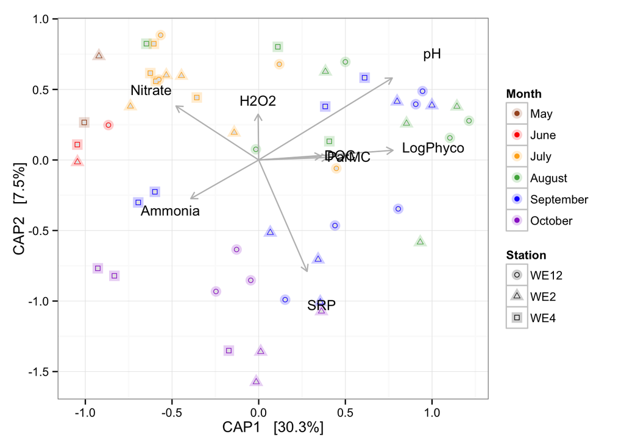

```r
cna <- subset_samples(moth_good,Fraction=="CNA")
# cna <-subset_samples(cna,Station!="WE4")
cna.scale<-scale_reads(cna,n = 10000)
cna.scale<-prune_samples(sample_sums(cna.scale)>0,cna.scale)


cna.scale.sub<-subset_samples(cna.scale,!is.na(LogPhyco) & !is.na(SRP)&
                                !is.na(DOC) & !is.na(pH)&!is.na(ParMC)&!is.na(H2O2))

bdist<-phyloseq::distance(physeq = cna.scale.sub,method = "bray")

sample_data(cna.scale.sub)$Month <- factor(sample_data(cna.scale.sub)$Month,
                                           levels=c("May","June","July","August",
                                                    "September","October","November"))



# CAP
cap.ord<-ordinate(physeq = cna.scale.sub,method = "CAP",
                  distance = bdist,
                  formula = ~ParMC+Nitrate+SRP+LogPhyco+Ammonia+DOC+pH+H2O2)


cap.plot <- plot_ordination(cna.scale.sub,cap.ord,color="Month",axes = c(1,2)) +
            aes(shape = Station) +
            geom_point(aes(colour = Month),alpha=.2, size = 4) +
            geom_point(colour="grey90", size = 1.5) +
            scale_color_manual(values=c("#a65628","red","#ffae19",
                                        "#4daf4a","#1919ff",
                                        "darkorchid3","magenta"))


# Now add the environmental variables as arrows
arrowmat = vegan::scores(cap.ord, display = "bp")

# Add labels, make a data.frame
arrowdf <- data.frame(labels = rownames(arrowmat), arrowmat)

# Define the arrow aesthetic mapping
arrow_map = aes(xend = CAP1, yend = CAP2, x = 0, y = 0,
                shape = NULL, color = NULL,
                label = labels)

label_map = aes(x = 1.3 * CAP1, y = 1.3 * CAP2, shape = NULL, color = NULL,
    label = labels)

arrowhead = arrow(length = unit(0.02, "npc"))

# Make a new graphic
p1 = cap.plot +
     geom_segment(arrow_map, size = .5,
                             data = arrowdf, color = "gray",
                             arrow = arrowhead) +
    geom_text(label_map, size = 4,face="bold",
                data = arrowdf,show_guide=FALSE)

p1
```

Do a permutational ANOVA on constrained axes used in ordination

```r
anova(cap.ord)
```

```
## Permutation test for capscale under reduced model
## Permutation: free
## Number of permutations: 999
##
## Model: capscale(formula = distance ~ ParMC + Nitrate + SRP + LogPhyco + Ammonia + DOC + pH + H2O2, data = data)
##          Df Variance      F Pr(>F)
## Model     8   3.2981 5.1227  0.001 ***
## Residual 42   3.3801
## ---
## Signif. codes:  0 '***' 0.001 '**' 0.01 '*' 0.05 '.' 0.1 ' ' 1
```

# Differential abundance of OTUs

Now we will test which OTUs are differentially abundant between our fraction with large algal colonies (>100um) and smaller algal colonies (53-100um)

Note: normally you should filter out low-abundance OTUs before running these tests. These low abundance OTUs will create the most noise in your model and are *maybe/probably* less important to your community than more abundant OTUs. I did not do that here because these two fractions i’m comparing have overall very low diversity

```r
library(DESeq2)
# Subset to just the samples from the 100um and 53um fractions
just53and100 <- subset_samples(moth_good, Fraction %in% c("100LTR","53LTR"))

# Convert phyloseq object to deseq object
# When creating your model, deseq always compares
fdeseq <- phyloseq_to_deseq2(just53and100,~Fraction)
#This step will estimate size factors, dispersion, and fit model. It will take a few minutes to run
fdeseq=DESeq(fdeseq)
```

```
## -- replacing outliers and refitting for 932 genes
## -- DESeq argument 'minReplicatesForReplace' = 7
## -- original counts are preserved in counts(dds)
```

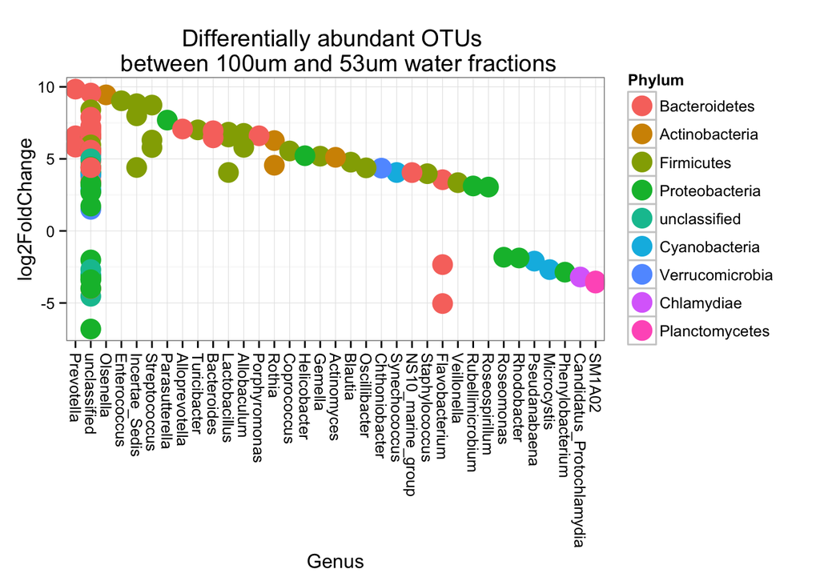

```r
#Store the results
res=results(fdeseq)

#Reorder the results according to the adjusted P-value (Adjusted because of multiple tests)
res=res[order(res$padj,na.last=NA),]

#Choose a threshold for p-value
alpha=.01

#Store only OTU's that were below that p-value
sigtab <- res[(res$padj<alpha),]

# Add in taxonomic names for OTUs into sigtab matrix
sigtab <- cbind(as(sigtab, "data.frame"), as(tax_table(moth_good)[rownames(sigtab),], "matrix"))

# Phylum
x = tapply(sigtab$log2FoldChange, sigtab$Phylum, function(x) max(x))
x = sort(x, TRUE)
sigtab$Phylum = factor(as.character(sigtab$Phylum), levels=names(x))

# Genus
x = tapply(sigtab$log2FoldChange, sigtab$Genus, function(x) max(x))
x = sort(x, TRUE)
sigtab$Genus = factor(as.character(sigtab$Genus), levels=names(x))

# Plot
theme_set(theme_bw())
ggplot(sigtab, aes(x=Genus, y=log2FoldChange, color=Phylum)) + geom_point(size=6) +
  theme(axis.text.x = element_text(angle = -90, hjust = 0, vjust=0.5)) +
  ggtitle("Differentially abundant OTUs \n between 100um and 53um water fractions")
```

Note: DESeq2 assumes the first level in your factor is the control. In this case, 100um comes before 53um, so OTUs that have a positive log2foldchange are more abundant in the 53um fraction than the 100um fraction and vice versa

# Functions

```r
### all the functions####

##### FUNCTIONS ########

# Scale reads using mcmurdie holmes method to a given library size of n
scale_reads <- function(physeq,n){
  physeq.scale <- transform_sample_counts(physeq, function(x) {(n*x/sum(x))})
  otu_table(physeq.scale) = floor(otu_table(physeq.scale))
  physeq.scale = prune_taxa(taxa_sums(physeq.scale)>0,physeq.scale)
  return(physeq.scale)
}

# Order dates correctly in a data frame
order_dates <- function(df){
  df$Date <- factor(df$Date, levels = c("5/27","6/10","6/16","6/30","7/8","7/14","7/21",
                                        "7/29","8/4","8/11","8/18","8/25","9/2","9/8","9/15",
                                        "9/23","9/29","10/6","10/15","10/20","10/27","11/3"))
  return(df)
}

# Function to run adonis test on a distance object and a categorical variable from a metadata data frame
doadonis <- function(physeq, category) {
  physeq.scale <- scale_reads(physeq,min(sample_sums(physeq)))
  bdist<-phyloseq::distance(physeq.scale,"bray")
  col = as(sample_data(physeq),"data.frame")[,category]
  adonis.bdist=adonis(bdist~col)
  print(adonis.bdist)
  paste("The Homogeneity of dispersion \n")


 # Homogeneity of dispersion test
  betatax=betadisper(bdist,col)
  p=permutest(betatax)
  print("The homogeneity of dispersion:")
  print(p$tab)
}


# Function to make a pcoa plot with bray-cutis distance where color variable is discrete
make_pcoa <- function(physeq){
  physeq.scale <- scale_reads(physeq,min(sample_sums(physeq)))
  sample_data(physeq.scale) <- order_dates(sample_data(physeq.scale))
  set.seed(1)
  physeq.bray.nmds = ordinate(physeq.scale,method="PCoA","bray")
}


# This function takes a phyloseq object, agglomerates OTU's to the desired taxonomic rank, prunes out OTUs below a certain relative proportion in a sample (ie 1% ) and melts the phyloseq object into long format.
transform_and_melt <- function(physeq, taxrank, prune){

  # Agglomerate all otu's by phylum level
  physeq_taxrank <- tax_glom(physeq,taxrank = taxrank)

  # Create a new phyloseq object which removes taxa from each sample below the prune parameter
  physeq_taxrank.prune <- transform_sample_counts(physeq_taxrank,
                                              function(x){x/sum(x)})
  otu_table(physeq_taxrank.prune)[otu_table(physeq_taxrank.prune) < prune] <- 0
  physeq_taxrank.prune <- prune_taxa(taxa_sums(physeq_taxrank.prune) > 0,
                                 physeq_taxrank.prune)

  # Set all samples from 8/11 to 0 because of bad sampling on that date
  w<-which(sample_data(physeq_taxrank.prune)$Date == "8/11")
  otu_table(physeq_taxrank.prune)[,w] <- 0

  # Melt into long format and sort by samplenum and phylum
  physeq_taxrank.long <- psmelt(physeq_taxrank.prune)
  physeq_taxrank.long <- arrange(physeq_taxrank.long,Samplenum,Phylum)


  # Reorder factor levels for dates
  physeq_taxrank.long <- order_dates(physeq_taxrank.long)

  # Reorder factor levers for stations
  physeq_taxrank.long$Station <- factor(physeq_taxrank.long$Station,
                                        levels=c("WE2","WE12","WE4"))

  # Reorder factor levels for Fraction. Change Fraction factor names
  physeq_taxrank.long$Fraction <- factor(physeq_taxrank.long$Fraction,
                                        levels=c("CNA","100LTR","53LTR","3NA","22NA"))

  levels(physeq_taxrank.long$Fraction) <- c("Full", "100um", "53um","3um","0.22um")

  # Return long data frame
  return(physeq_taxrank.long)
}

# This function takes  a data frame in long format (such as the output from transform_and_melt) and produces a stacked barplot of community composition.
make_tax_barplot<-function(df,x,y,tax,facet,title,colors,xlab,ylab,relative,outline,guide){
  ggplot(df,aes_string(x=x,y=y,fill=tax)) +
        facet_grid(reformulate(facet))+
        geom_bar(stat="identity",show_guide=guide)+
    scale_fill_manual(values = colors) +
    scale_x_discrete(breaks=c("6/10","7/8",
                              "8/4","9/2","10/6","11/3"),
                      labels=c("Jun", "Jul",
                                "Aug", "Sep",  "Oct","Nov"),
                     drop=FALSE
                     )+
    theme(axis.title.x = element_text(size=16,face="bold"),
          axis.text.x = element_text(angle=50, colour = "black", vjust=1, hjust = 1, size=13),
          axis.text.y = element_text(colour = "black", size=10),
          axis.title.y = element_text(face="bold", size=16),
          plot.title = element_text(size = 18),
          legend.title = element_text(size=14),
          legend.text = element_text(size = 13),
          legend.position="right",
          strip.text.x = element_text(size=16, face="bold"),
          strip.text.y = element_text(size=16, face="bold"),
          strip.background = element_rect(color="white",size=2,fill=NA),
          panel.grid.major = element_blank(), panel.grid.minor = element_blank(),
          panel.border = element_rect(colour = "black",fill=NA,size=1.5),
          panel.margin = unit(1, "lines"),
          panel.background = element_rect(fill="#a8a8a8")
      ) +
    guides(fill = guide_legend(reverse= TRUE,keywidth=1,keyheight=1))+
    xlab(xlab)+
    ylab(ylab)+
    ggtitle(title)+
    if (relative){
          geom_bar(stat="identity",position="fill", colour=outline,show_guide=FALSE)
        } else {
          geom_bar(stat="identity",colour=outline,show_guide=FALSE)
    }

}
```